# Autoregressive models and simulation: exercise

Ben Bolker

10:30 21 September 2015

## Goals

Work through basic model-fitting and parametric bootstrapping yourself, R coding reminders. Similar to class notes from Thursday, but less slick and more pedagogical.

## Topics

- semi-simple autoregressive models
- tips for statistical computing
- parametric bootstrapping

## Semi-simple AR models

Run this code to let current versions of R know about `sigma`, which is added in the development version of R: from the [NEWS file](http://stat.ethz.ch/R-manual/R-devel/doc/html/NEWS.html),

> New S3 generic function sigma() with methods for extracting the estimated standard deviation aka “residual standard deviation” from a fitted model.

```r
if (getRversion() < '3.3.0') {
    sigma <- function(object, ...) UseMethod("sigma")
    sigma.default <- function(object,...) {
        summary(object)$sigma
    }
}
```

It’s good practice to load all required packages at the head of your code; it’s sometimes frustrating to get most of the way into an analysis and then have to stop to install packages. Remember that you only have to install packages once per R installation (re-installation is only needed after “major” releases, e.g. 3.1 $to$ 3.2).

Load data from Dennis and Taper on Yellowstone grizzlies. To load data you need to set your directory structure and *working directory* properly (this is often the hardest part of an introductory R session!).

You can either:

- set up your directories (folders) for class materials to mirror the Github repository, with a `data` directory parallel to your working directory (which on the repository is `notes`), *or*
- keep the data and R scripts in the same file and modify the file below to `"DTgrizzly.txt"`.
- The simplest way to set the working directory is with the `Session > Set Working Directory > To Source File Location` menu item; you can also use `setwd()` from the console.

```r
grizzly <- read.table("../data/DTgrizzly.txt",header=TRUE)
```

- **Question**: what happens if you forget `header=TRUE`? Unless you know the answer already, try it, and use `str(badgrizzly)` to check out the result. (One good reason to keep your data in CSV rather than space-separated files, besides the fact that they can be exported from Excel and can handle strings containing spaces, is that `read.csv()` uses `header=TRUE` by default.)

Lag the variables by dropping the first and last elements respectively.

```r
nlag1 <- grizzly$n[-1]
nlag0 <- grizzly$n[-length(grizzly$n)]
r <- log(nlag1/nlag0)
```

- **Q**: what happens if you forget to make `nlag0` and just compute `nlag1/grizzly$n`? (If all this is new to you, *stop and print the values of `nlag0` and `nlag1`. It may be helpful to align them using `data.frame(nlag0,nlag1)`.)

Look at the data:

```r
plot(n~time,data=grizzly,type="b",xlab="time",ylab="pop size")
plot(nlag0,r,xlab="pop size",ylab="logarithmic growth rate")
```

Put the data together and run the linear regression:

```r
dd <- data.frame(x=log(nlag0),xlag1=log(nlag1))
m2 <- lm(xlag1~offset(x)+exp(x),data=dd)
```

Use `coef()` and `summary()` to look at the results.

Stop and convince yourself that the results are identical if you subtract `xlag1` from both sides of the equation (i.e., don’t use `offset`).

Define the MLE variance, which is $\mbox{SSQ}/n = \sigma^2_{\textrm{unbiased}} \cdot (n-2)/n$:

```r
var.mle <- function(m)
    sigma(m)^2*df.residual(m)/nobs(m)
```

Simplified model:

```r
## R tip: use update() when possible to simplify code
m1 <- update(m2, . ~ offset(x))
c(coef(m1),var.mle(m1))
```

```
## (Intercept)
##  0.04139847  0.01490303
```

- **Question**: confirm that this is equivalent to fitting the simple model from scratch.

## Simulation

Define simulation code. (Not too much to say here. It might make the function look a little bit simpler to use parameters `{a,b,sigma,x0}` rather than `{fit,x0}`, but then we would have to do all the extraction of coefficients outside of the function anyway …)

```r
## simulate new data, add starting value
simfun <- function(fit,x0=log(grizzly$n[1])) {
    cc <- coef(fit)
    a <- cc[1]
    ## make the function work for either constant or regression model
    b <- if (length(cc)==2) coef(fit)[2] else 0
    sigma <- sqrt(var.mle(fit))
    ## as usual, half the code is setup: the next three lines are
    ##   the actual meat
    res <- c(x0,numeric(nobs(fit)+1))
    for (i in 2:length(res)) {
        res[i] <- res[i-1]+a+b*exp(res[i-1])+rnorm(1,sd=sigma)
    }
    res
}
```

Test simulation function:

```r
sim2 <- replicate(200,simfun(m2))
sim1 <- replicate(200,simfun(m1))
```

`replicate()` is convenient, but may feel too magical. (I always get confused because the syntax is `replicate(n,expression)`, whereas `replicate(expression,n)` would seem more natural. [What happens if you type `replicate(simfun(m2),200)` ?])

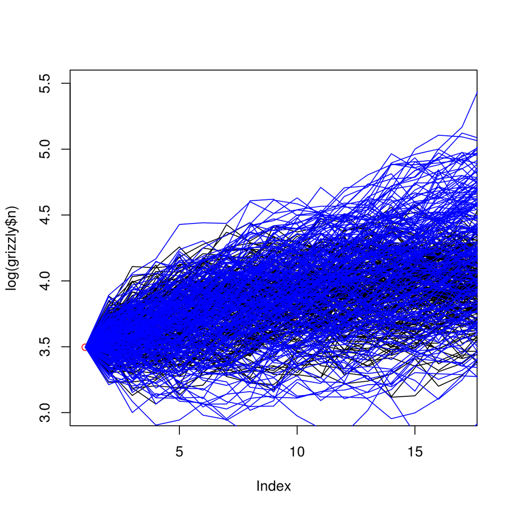

```r
plot(log(grizzly$n),col="red",ylim=c(3,5.5))
matlines(sim2,col="black",lty=1)
matlines(sim1,col="blue",lty=1)
```

If you feel like it, add a legend …

Here is a less-magical way to run the parametric bootstrap:

```r
nboot <- 2000
res <- matrix(NA,nrow=nboot,ncol=3)
set.seed(101)
for (i in 1:nboot) {
    x <- simfun(m2)
    dd <- data.frame(xlag1=x[-1],x=x[-length(x)])
    bootfit <- update(m2,data=dd)
    res[i,] <- c(coef(bootfit),var.mle(bootfit))
}
```

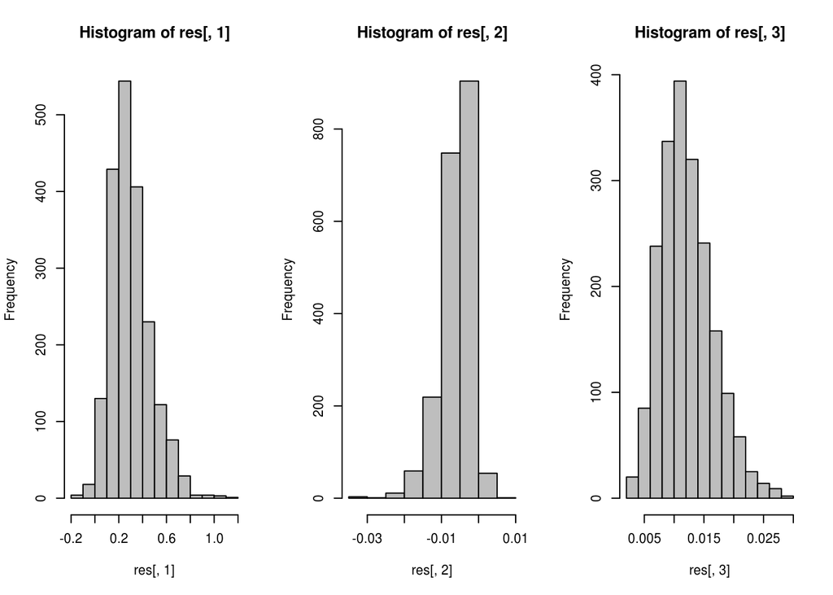

```r
par(mfrow=c(1,3))
hist(res[,1],col="gray")
hist(res[,2],col="gray")
hist(res[,3],col="gray")
```

```r
t(apply(res,2,quantile,c(0.025,0.975)))
```

```
##              2.5%        97.5%
## [1,]  0.043354116 6.757800e-01
## [2,] -0.016377337 5.957045e-05
## [3,]  0.005109054 2.192644e-02
```

Compare this with the `confint()` values for the original model.

Now suppose we want to do a hypothesis test.

We can retrieve the $F$ statistic for the difference between models this way:

```r
(a1 <- anova(m1,m2))
```

```
## Analysis of Variance Table
##
## Model 1: xlag1 ~ offset(x)
## Model 2: xlag1 ~ offset(x) + exp(x)
##   Res.Df     RSS Df Sum of Sq     F Pr(>F)
## 1     15 0.23845
## 2     14 0.23239  1 0.0060579 0.365 0.5554
```

```r
F_obs <- a1[2,"F"]
```

```r
nboot <- 2000
res2 <- numeric(nboot)
set.seed(101)
for (i in 1:nboot) {
    x <- simfun(m1)
    dd <- data.frame(xlag1=x[-1],x=x[-length(x)])
    bootm1 <- update(m1,data=dd)
    bootm2 <- update(m2,data=dd)
    res2[i] <- anova(bootm1,bootm2)[2,"F"]
}
```

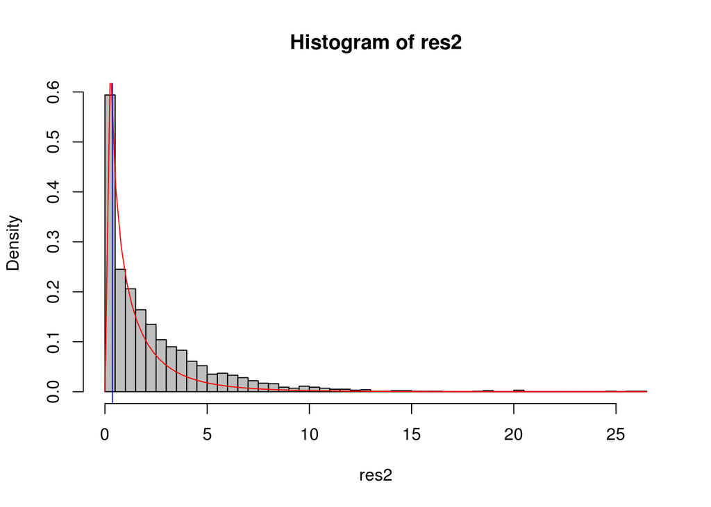

```r
hist(res2,col="gray",freq=FALSE,breaks=50)
curve(df(x,1,14),add=TRUE,col="red")
abline(v=F_obs,col="blue")
```

```r
sum(res2>=F_obs)/length(res2)
```

```
## [1] 0.7485
```

```r
## DT get 0.72 instead ...
```

We can also use `mean(res2>=F_obs)` as a shortcut for `sum(res2>=F_obs)/length(res2)`.

## If you’re finished/bored …

- re-do the analysis for the elk data set in `notes/DTelk.txt`. Dennis and Taper give the results as
- model 1 (density-independent): $a=0.0145$, $\sigma^2=0.0685$
- model 2 (density-dependent): $a=0.731$, $b=-4.93 \times 10^{-4}$, $\sigma^2=0.0465$
- $\hat P = 0.044$
- write a general function to do these PB tests
- Try the parametric bootstrap using the likelihood ratio test (e.g., see `anova(m1,m2,test="Chisq")`) instead. Why is the answer different?
- Explore alternate models for the data. The *Gompertz state-space model* uses $X_t=X_{t-1} + a+ b X_{t-1} + \sigma Z_t$ (i.e., substituting $bX_{t-1}$ for $b \exp(X_{t-1}$). Another alternative would be a *generalized Ricker*, using $X_t = (c+1) X_{t-1} + a + b \exp{X_t-1} + \sigma Z_t$ …